# PML Course Project

WhitefishDontJump

January 2015

The source of data for this project is from

Velloso, E.; Bulling, A.; Gellersen, H.; Ugulino, W.; Fuks, H. **Qualitative Activity Recognition of Weight Lifting Exercises.** Proceedings of 4th International Conference in Cooperation with SIGCHI (Augmented Human ’13) . Stuttgart, Germany: ACM SIGCHI, 2013

Read more: http://groupware.les.inf.puc-rio.br/har#ixzz3MCvfqKcP

### Synopsis

#### Exploration, Cleaning and Model Development

1. Response is categorical (factor).
2. The predictors, after cleaning, are largely integer or numeric.
3. I will retain user_name as a factor variable. It is possible that individual users uniquely condition the range of responses in other predictors.
4. I plan to use random forest (via caret’s train function), and will use a three fold cross validation of rf results.
5. There are 53 predictor variables after cleaning the raw dataset. Given the size of the dataset, and selecting 50% of the training set, a 3 fold validation will yield more than 6000 observations per fold, on a base of more than 9800 observations in one half of the training dataset.

#### Results Summary

1. Random Forest yielded a highly accurate predictive model with an estimated out of sample error rate of less than 1%.
2. While the response was somewhat conditioned by which user (variable user_name) was measured, the factor user_name had minimal importance in the resulting model.

```r
    training <- read.csv("pml-training.csv",
                         na.strings = c("NA", "", "#DIV/0!"))

    testing <- read.csv("pml-testing.csv",
                        na.strings = c("NA", "", "#DIV/0!"))

##  View(training)

### lots of missing data and/or NAs ##

# I will be removing any columns with NAs as predictors in the training set.

    cols2get <- colSums(is.na(training))==0
    cleantraining <- training[, cols2get]

###  leaves 60 columns
## same cleaning for testing data (optional choice on my part)

    cols2get2 <- colSums(is.na(testing))==0
    cleantesting <- testing[,cols2get2]

### remove row "X", as well as time date window columns
###  which are not related to prediction of 'classe'

    cleantraining <- cleantraining[,c(-1, -3, -4, -5, -6, -7)]
    cleantesting <- cleantesting[,c(-1, -3, -4, -5, -6, -7)]

    require(caret)
## create new partition in 'training set' and create training1, testing1 set.
## I will use training1 to create the model and testing1 to estimate out of sample error.

    set.seed(150119) ## for repeatability

    trindex <- as.vector(createDataPartition(cleantraining$classe,
                                             p = 0.5, list = FALSE))

    training1 <- cleantraining[trindex,]
    testing1  <- cleantraining[-trindex,]

##  Initial model with 1/2 of training set and 3 fold cross validation,
##  using the random forest method and caret's train() function.
##  Afterwards, test the model with other half of training set
##  to estimate out of sample accuracy.

    controla <- trainControl(method="cv", number = 3)

    modela <- train(classe~.,
                    data = training1,
                    method="rf",
                    trControl = controla)
## determine in sample error, which vars are relevant and relative importance

    modela
```

```
## Random Forest
##
## 9812 samples
##   53 predictor
##    5 classes: 'A', 'B', 'C', 'D', 'E'
##
## No pre-processing
## Resampling: Cross-Validated (3 fold)
##
## Summary of sample sizes: 6541, 6542, 6541
##
## Resampling results across tuning parameters:
##
##   mtry  Accuracy   Kappa      Accuracy SD  Kappa SD
##    2    0.9799219  0.9745961  0.005442004  0.006893732
##   29    0.9822664  0.9775618  0.001837294  0.002331750
##   57    0.9711575  0.9635101  0.002174092  0.002759118
##
## Accuracy was used to select the optimal model using  the largest value.
## The final value used for the model was mtry = 29.
```

```r
    confusionMatrix(modela) ## in sample error
```

```
## Cross-Validated (3 fold) Confusion Matrix
##
## (entries are percentages of table totals)
##
##           Reference
## Prediction    A    B    C    D    E
##          A 28.3  0.4  0.0  0.0  0.0
##          B  0.1 18.8  0.3  0.0  0.1
##          C  0.0  0.1 17.0  0.4  0.0
##          D  0.0  0.0  0.2 15.9  0.1
##          E  0.0  0.0  0.0  0.0 18.2
```

```r
    varImp(modela)
```

```
## rf variable importance
##
##   only 20 most important variables shown (out of 57)
##
##                      Overall
## roll_belt             100.00
## pitch_forearm          58.46
## yaw_belt               51.54
## magnet_dumbbell_z      47.38
## magnet_dumbbell_y      45.54
## pitch_belt             43.81
## roll_forearm           42.48
## accel_dumbbell_y       25.60
## roll_dumbbell          20.11
## accel_forearm_x        19.28
## magnet_dumbbell_x      18.02
## accel_dumbbell_z       15.85
## magnet_belt_z          15.65
## accel_belt_z           15.29
## gyros_belt_z           14.97
## magnet_forearm_z       14.77
## magnet_belt_y          14.04
## total_accel_dumbbell   12.95
## magnet_belt_x          12.59
## yaw_arm                12.26
```

```r
##  All factor levels of user_name, except Eurico, had relative importance of less than 1. Eurico's activity differed from those of the other users: his user_name factor level had relative importance of 2.35 on the scaled varImp results, compared to 0.54 for Charles, and smaller values for other users. I conclude that user_name had minimal importance in the final model.


## Out of Sample Error estimate

##  I will estimate the out of sample error by applying the model to the second part of the training set (named testing1).

    predicta  <- predict(modela, testing1)

    confusionMatrix(predicta,testing1$classe)
```

```
## Confusion Matrix and Statistics
##
##           Reference
## Prediction    A    B    C    D    E
##          A 2780   10    0    0    0
##          B    6 1870   16    0    0
##          C    4   16 1686   19    4
##          D    0    2    9 1589    7
##          E    0    0    0    0 1792
##
## Overall Statistics
##
##                Accuracy : 0.9905
##                  95% CI : (0.9884, 0.9923)
##     No Information Rate : 0.2844
##     P-Value [Acc > NIR] : < 2.2e-16
##
##                   Kappa : 0.988
##  Mcnemar's Test P-Value : NA
##
## Statistics by Class:
##
##                      Class: A Class: B Class: C Class: D Class: E
## Sensitivity            0.9964   0.9852   0.9854   0.9882   0.9939
## Specificity            0.9986   0.9972   0.9947   0.9978   1.0000
## Pos Pred Value         0.9964   0.9884   0.9751   0.9888   1.0000
## Neg Pred Value         0.9986   0.9965   0.9969   0.9977   0.9986
## Prevalence             0.2844   0.1935   0.1744   0.1639   0.1838
## Detection Rate         0.2834   0.1906   0.1719   0.1620   0.1827
## Detection Prevalence   0.2844   0.1929   0.1762   0.1638   0.1827
## Balanced Accuracy      0.9975   0.9912   0.9900   0.9930   0.9969
```

```r
## fit is very good, accuracy 0.9905, and does not seem to be overfitting on the testing1 set. I am satisfied with the model result and also believe that using the entire training set can only increase the chance of overfitting.

## Based on this favorable result, I use this model, 'modela', on the class testing set:

    answers <- predict(modela, cleantesting)

    answers
```

```
##  [1] B A B A A E D B A A B C B A E E A B B B
## Levels: A B C D E
```

```r
## submitting 'answers' (via the function provided), scored 20 of 20 correct.
```

Conclusion:

The random forest method, properly tuned for 3 fold cross validation and a controlled training set size, created a prediction model with greater than 99% accuracy in an out of sample test.

I also include a scatter plot of total_accel_arm and roll_belt, colored by user_name. While the plot confirms differences among users, it is not very important in the final model, as reported by varImp().

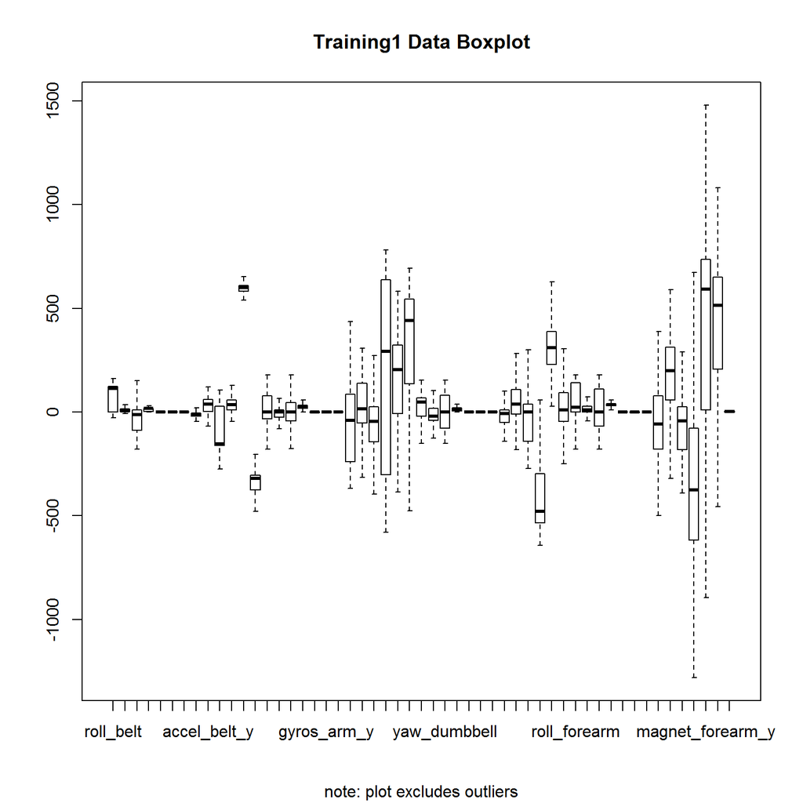

```r
    boxplot(training1[,-1], outline=FALSE,
            main="Training1 Data Boxplot",
            sub="note: plot excludes outliers")
```

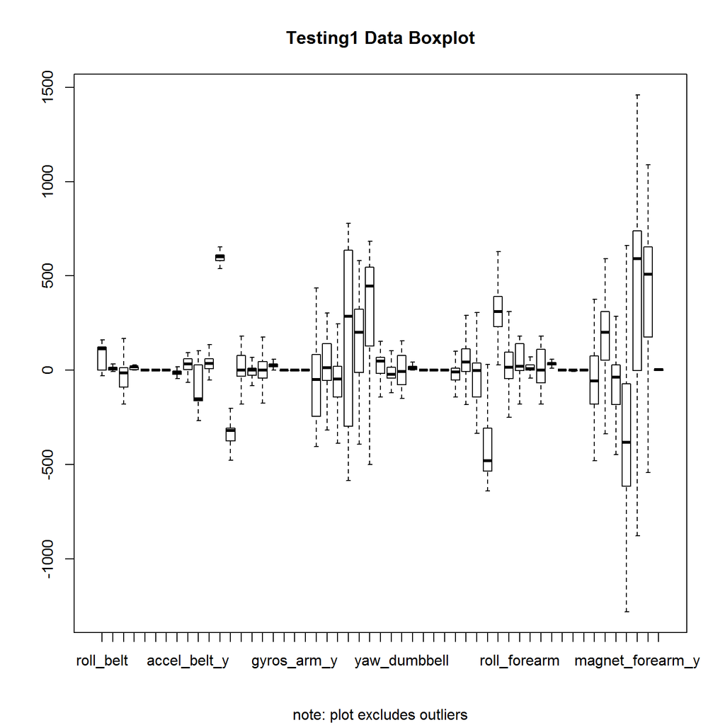

```r
    boxplot(testing1[,-1], outline=FALSE,
            main="Testing1 Data Boxplot",
            sub="note: plot excludes outliers")
```

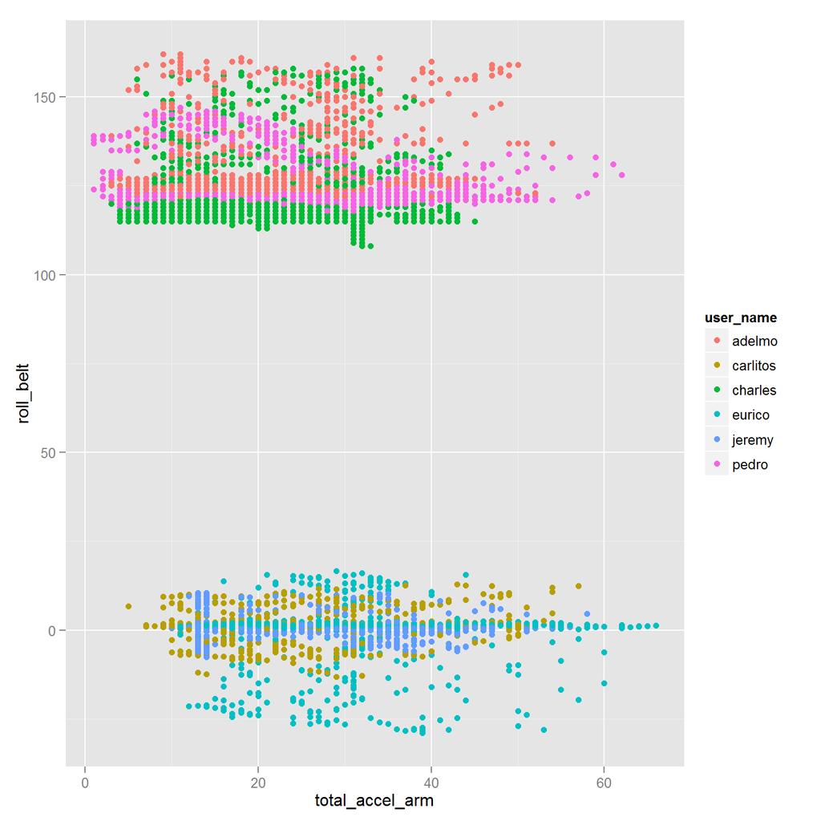

```r
    qplot(total_accel_arm, roll_belt, data=training1, color = user_name)
```